# Part I - Ford GoBike

## Introduction

In this project, I will explore and visualize data from the **Ford GoBike bike-sharing system**, specifically the **February 2019 trip data**. The dataset contains information about individual bike trips taken in the San Francisco Bay Area, including trip duration, user type, station locations, and rider demographics.

The project is divided into two main parts:

1. **Exploratory Data Analysis (EDA)** – I will use Python visualization libraries such as `Pandas`, `Matplotlib`, and `Seaborn` to analyze patterns and relationships in the data. This includes univariate, bivariate, and multivariate analysis to understand user behavior, trip duration patterns, and station popularity.
2. **Explanatory Data Visualization** – I will present the most interesting findings from the EDA using polished, well-designed visualizations. These visualizations will help communicate insights clearly and effectively to an audience.

The goal of this project is to demonstrate the power of data visualization in uncovering trends and sharing insights from real-world datasets.

## 📊 Dataset Overview

The dataset used in this project is the **Ford GoBike System Data for February 2019**, available on Kaggle: https://www.kaggle.com/datasets/chirag02/ford-gobike-2019feb-tripdata

This dataset includes detailed information on **183,412 individual bike trips** made in the San Francisco Bay Area during February 2019. Each record corresponds to one trip and includes the following key attributes:

- **`duration_sec`**: Length of the trip in seconds.
- **`start_time`, `end_time`**: Timestamps of when the trip started and ended.
- **`start_station_id`, `end_station_id`**: Unique identifiers for the stations.
- **`start_station_name`, `end_station_name`**: Names of the start and end stations.
- **`start_lat`, `start_lon`, `end_lat`, `end_lon`**: Geographic coordinates of stations.
- **`bike_id`**: Identifier of the bike used.
- **`user_type`**: Indicates whether the rider was a **Subscriber** (monthly/yearly member) or **Customer** (casual rider).
- **`member_gender`** and **`member_birth_year`**: Demographic information about the user.
- **`bike_share_for_all_trip`**: Whether the trip was part of the “Bike Share for All” program.

This dataset is well-suited for time-based, location-based, and demographic analysis, offering great potential for discovering insights about urban mobility patterns.

## Preliminary Wrangling

```python
# Import all packages
import numpy as np
import pandas as pd
import matplotlib.pyplot as plt
import seaborn as sns
```

**Data Upload Method**

To upload the dataset, I used **Google Drive integration** instead of uploading from my local machine. This method is faster and more efficient, especially for larger files like the Ford GoBike dataset (~39 MB). By mounting Google Drive in Colab, I was able to read the CSV file directly without re-uploading it each time.

```python
from google.colab import drive
drive.mount('/content/drive')
```

```python
import pandas as pd

file_path = '/content/drive/MyDrive/Dataset/201902-fordgobike-tripdata.csv'
bike = pd.read_csv(file_path)
bike.head()
```

|  | duration_sec | start_time | end_time | start_station_id | start_station_name | start_station_latitude | start_station_longitude | end_station_id | end_station_name | end_station_latitude | end_station_longitude | bike_id | user_type | member_birth_year | member_gender | bike_share_for_all_trip |
| --- | --- | --- | --- | --- | --- | --- | --- | --- | --- | --- | --- | --- | --- | --- | --- | --- |
| 0 | 52185 | 2019-02-28 17:32:10.1450 | 2019-03-01 08:01:55.9750 | 21.0 | Montgomery St BART Station (Market St at 2nd St) | 37.789625 | -122.400811 | 13.0 | Commercial St at Montgomery St | 37.794231 | -122.402923 | 4902 | Customer | 1984.0 | Male | No |
| 1 | 42521 | 2019-02-28 18:53:21.7890 | 2019-03-01 06:42:03.0560 | 23.0 | The Embarcadero at Steuart St | 37.791464 | -122.391034 | 81.0 | Berry St at 4th St | 37.775880 | -122.393170 | 2535 | Customer | NaN | NaN | No |
| 2 | 61854 | 2019-02-28 12:13:13.2180 | 2019-03-01 05:24:08.1460 | 86.0 | Market St at Dolores St | 37.769305 | -122.426826 | 3.0 | Powell St BART Station (Market St at 4th St) | 37.786375 | -122.404904 | 5905 | Customer | 1972.0 | Male | No |
| 3 | 36490 | 2019-02-28 17:54:26.0100 | 2019-03-01 04:02:36.8420 | 375.0 | Grove St at Masonic Ave | 37.774836 | -122.446546 | 70.0 | Central Ave at Fell St | 37.773311 | -122.444293 | 6638 | Subscriber | 1989.0 | Other | No |
| 4 | 1585 | 2019-02-28 23:54:18.5490 | 2019-03-01 00:20:44.0740 | 7.0 | Frank H Ogawa Plaza | 37.804562 | -122.271738 | 222.0 | 10th Ave at E 15th St | 37.792714 | -122.248780 | 4898 | Subscriber | 1974.0 | Male | Yes |

🧪 Dataset Assessment Function

The `assess_dataframe()` function is a utility to quickly inspect the structure and quality of a dataset. It performs the following checks:

- 🔍 **Missing Values**: Shows how many null values exist in each column.
- 🧾 **Duplicate Rows**: Counts any duplicate entries.
- 🔍 **Data Types**: Displays the type of data in each column.
- 🧠 **Info Summary**: Gives an overview of the dataframe’s shape and memory usage.
- 📊 **Descriptive Statistics**: Summarizes key statistics (mean, min, max, etc.) for numeric columns.

This function helps guide data cleaning decisions and ensures the dataset is ready for analysis.

```python
def assess_dataframe(df, name):
    print(f"# 📘 Dataset Assessment - {name}")
    print("\n🔍 Missing Values (.isnull().sum()):")
    print(df.isnull().sum())

    print("\n" + "="*80)
    print("🔍 Duplicate Rows (.duplicated()):")
    print("Total Duplicates:", df.duplicated().sum())

    print("\n" + "="*80)
    print("🔍 Data Types (.dtypes):")
    print(df.dtypes)

    print("\n" + "="*80)
    print("🔍 DataFrame Info (.info()):")
    df.info()

    print("\n" + "="*80)
    print("🔍 Descriptive Statistics (.describe()):")
    print(df.describe())
```

```python
assess_dataframe(bike, "Ford GoBike")
```

```
# 📘 Dataset Assessment - Ford GoBike

🔍 Missing Values (.isnull().sum()):
duration_sec                  0
start_time                    0
end_time                      0
start_station_id            197
start_station_name          197
start_station_latitude        0
start_station_longitude       0
end_station_id              197
end_station_name            197
end_station_latitude          0
end_station_longitude         0
bike_id                       0
user_type                     0
member_birth_year          8265
member_gender              8265
bike_share_for_all_trip       0
dtype: int64

================================================================================
🔍 Duplicate Rows (.duplicated()):
Total Duplicates: 0

================================================================================
🔍 Data Types (.dtypes):
duration_sec                 int64
start_time                  object
end_time                    object
start_station_id           float64
start_station_name          object
start_station_latitude     float64
start_station_longitude    float64
end_station_id             float64
end_station_name            object
end_station_latitude       float64
end_station_longitude      float64
bike_id                      int64
user_type                   object
```

[output cut: 47 more lines]

```
min                -122.453704        3.000000             37.317298
25%                -122.412408       44.000000             37.770407
50%                -122.398285      100.000000             37.781010
75%                -122.286533      235.000000             37.797320
max                -121.874119      398.000000             37.880222

       end_station_longitude        bike_id  member_birth_year
count          183412.000000  183412.000000      175147.000000
mean             -122.352250    4472.906375        1984.806437
std                 0.116673    1664.383394          10.116689
min              -122.453704      11.000000        1878.000000
25%              -122.411726    3777.000000        1980.000000
50%              -122.398279    4958.000000        1987.000000
75%              -122.288045    5502.000000        1992.000000
max              -121.874119    6645.000000        2001.000000
```

📂 What is the structure of your dataset?

The dataset consists of **183,412 rows** and **16 columns**, where each row represents a bike trip taken in February 2019 in the San Francisco Bay Area. It includes both **numerical features** (e.g., `duration_sec`, `member_birth_year`, coordinates) and **categorical features** (e.g., `user_type`, `member_gender`, `start_station_name`).

- ✅ No duplicate rows found.
- ⚠️ Missing values exist in:
  - `start_station_id`, `start_station_name`, `end_station_id`, `end_station_name` → 197 missing
  - `member_birth_year`, `member_gender` → 8,265 missing
- 🕒 `start_time` and `end_time` are stored as strings (`object`) and should be converted to datetime format for time-based analysis.

🎯 What is/are the main feature(s) of interest in your dataset?

The primary feature of interest is **`duration_sec`**, which represents the trip duration in seconds. I aim to understand what factors influence the length of a trip and how it differs based on user type, gender, time of day, and other conditions.

🔍 What features support your investigation?

The following features will help support the analysis of trip duration:

- **`start_time`, `end_time`** – for extracting hour, day, and weekday/weekend trends.
- **`user_type`** – to compare trip behavior between Subscribers and Customers.
- **`member_gender`, `member_birth_year`** – for exploring demographic influences.
- **`start_station_name`, `end_station_name`** – to detect popular routes and location-based patterns.
- **`bike_share_for_all_trip`** – to evaluate differences in behavior for affordability program participants.

**Data Cleaning**

```python
# Step 1: Convert time columns to datetime
bike['start_time'] = pd.to_datetime(bike['start_time'])
bike['end_time'] = pd.to_datetime(bike['end_time'])

# Step 2: Drop rows with missing demographic or station name data
bike_clean = bike.dropna(subset=['start_station_name', 'end_station_name', 'member_gender', 'member_birth_year'])

# Step 3: Filter out unrealistic trip durations (e.g., less than 1 minute or more than 2 hours)
bike_clean = bike_clean[(bike_clean['duration_sec'] >= 60) & (bike_clean['duration_sec'] <= 7200)]

# Step 4: Extract hour and day for later exploration
bike_clean['start_hour'] = bike_clean['start_time'].dt.hour
bike_clean['day_of_week'] = bike_clean['start_time'].dt.day_name()
```

```python
# Preview cleaned data
bike_clean.info()
```

```
<class 'pandas.core.frame.DataFrame'>
Index: 174414 entries, 4 to 183411
Data columns (total 18 columns):
 #   Column                   Non-Null Count   Dtype
---  ------                   --------------   -----
 0   duration_sec             174414 non-null  int64
 1   start_time               174414 non-null  datetime64[ns]
 2   end_time                 174414 non-null  datetime64[ns]
 3   start_station_id         174414 non-null  float64
 4   start_station_name       174414 non-null  object
 5   start_station_latitude   174414 non-null  float64
 6   start_station_longitude  174414 non-null  float64
 7   end_station_id           174414 non-null  float64
 8   end_station_name         174414 non-null  object
 9   end_station_latitude     174414 non-null  float64
 10  end_station_longitude    174414 non-null  float64
 11  bike_id                  174414 non-null  int64
 12  user_type                174414 non-null  object
 13  member_birth_year        174414 non-null  float64
 14  member_gender            174414 non-null  object
 15  bike_share_for_all_trip  174414 non-null  object
 16  start_hour               174414 non-null  int32
 17  day_of_week              174414 non-null  object
dtypes: datetime64[ns](2), float64(7), int32(1), int64(2), object(6)
memory usage: 24.6+ MB
```

🧹 Data Cleaning Steps

Before conducting univariate analysis, basic cleaning was applied:

- **Converted** `start_time` and `end_time` to datetime format to allow time-based analysis.
- **Removed rows with missing values** in key columns like station names, `member_gender`, and `member_birth_year`, since these fields are essential for demographic and location-based insights.
- **Filtered trip durations** to keep only reasonable values (between 60 seconds and 2 hours).
- **Created new features**:
  - `start_hour`: Hour of day the trip started
  - `day_of_week`: Name of the weekday the trip occurred

These steps ensure that the upcoming visualizations are based on clean and reliable data.

```python
bike = bike_clean.copy()
```

## Univariate Exploration Starter

General Plot Setup Function

```python
def setup_plot(title='', xlabel='', ylabel='', figsize=(10, 6), log_x=False, rotation=0):
    """
    Set up a consistent plot layout for any seaborn/matplotlib chart.
    """
    plt.figure(figsize=figsize)
    plt.title(title)
    plt.xlabel(xlabel)
    plt.ylabel(ylabel)
    if log_x:
        plt.xscale('log')
    plt.grid(True)
    plt.xticks(rotation=rotation)
```

Histogram for duration_sec

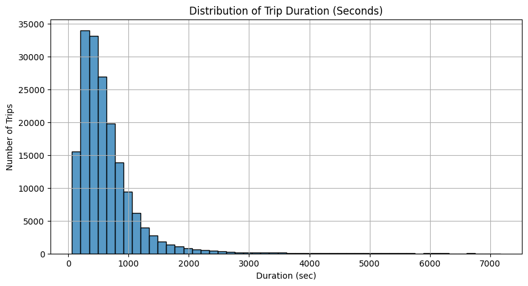

```python
setup_plot(
    title='Distribution of Trip Duration (Seconds)',
    xlabel='Duration (sec)',
    ylabel='Number of Trips',
    figsize=(10, 5),
    log_x=False
)
sns.histplot(data=bike_clean, x='duration_sec', bins=50)
plt.show()
```

Count plot for user_type

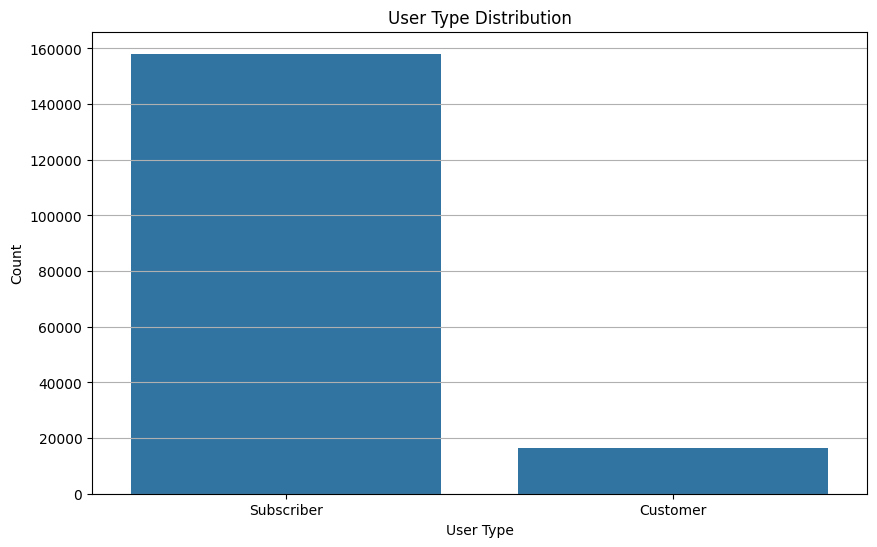

```python
setup_plot(
    title='User Type Distribution',
    xlabel='User Type',
    ylabel='Count'
)
sns.countplot(data=bike_clean, x='user_type')
plt.show()
```

Bar plot of average trip duration by user type

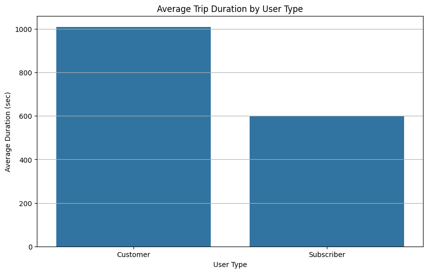

```python
avg_duration = bike_clean.groupby('user_type')['duration_sec'].mean().reset_index()

setup_plot(
    title='Average Trip Duration by User Type',
    xlabel='User Type',
    ylabel='Average Duration (sec)'
)
sns.barplot(data=avg_duration, x='user_type', y='duration_sec')
plt.show()
```

🧠 Discuss the distribution(s) of your variable(s) of interest

The distribution of `duration_sec` is clearly **right-skewed**, with the majority of trips lasting under 1,000 seconds (approximately 16 minutes). Very long trips are rare, but they extend the tail of the distribution significantly. This skew is typical in usage data, where most users take shorter trips. A log transformation or filtering could improve visibility of detail in the lower range.

🧠 Were there any unusual distributions or transformations?

No transformation was applied yet, but the long-tailed nature of `duration_sec` suggests it may be helpful in future steps.

In terms of categorical variables:

- **User Type** shows a **strong imbalance**, with most trips taken by **Subscribers** rather than **Customers**.
- Interestingly, the **average trip duration** is **longer for Customers** than Subscribers, which may indicate different use patterns (e.g., recreational vs. commuting).

No significant data quality issues were observed in the univariate distributions after initial cleaning.

## Bivariate Exploration

Scatter Plot – start_hour vs. duration_sec

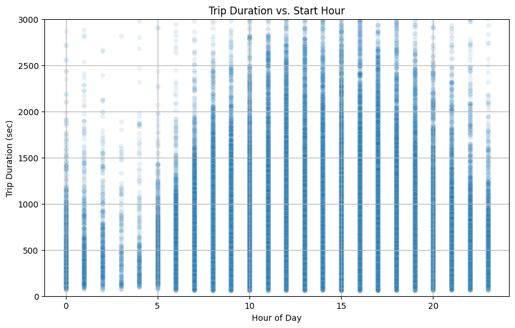

```python
setup_plot(
    title='Trip Duration vs. Start Hour',
    xlabel='Hour of Day',
    ylabel='Trip Duration (sec)'
)
sns.scatterplot(data=bike_clean, x='start_hour', y='duration_sec', alpha=0.1)
plt.ylim(0, 3000)  #cap to remove extreme outliers visually
plt.show()
```

Line Plot: Average Trip Duration by Start Hour

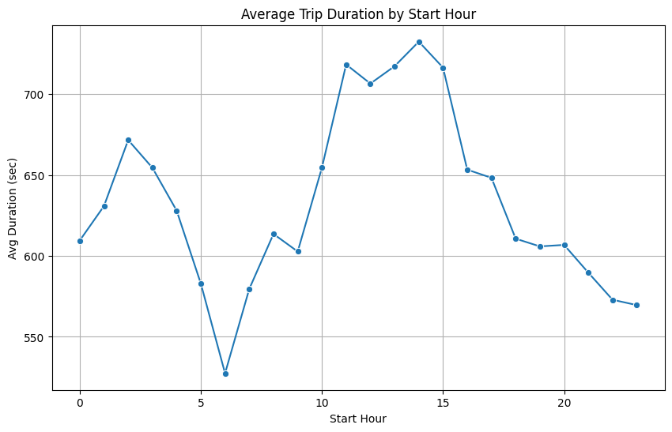

```python
avg_by_hour = bike_clean.groupby('start_hour')['duration_sec'].mean().reset_index()

setup_plot(
    title='Average Trip Duration by Start Hour',
    xlabel='Start Hour',
    ylabel='Avg Duration (sec)'
)
sns.lineplot(data=avg_by_hour, x='start_hour', y='duration_sec', marker='o')
plt.show()
```

🔍 Comparison: Scatter Plot vs. Line Plot for Trip Duration and Start Hour

- A **morning dip** in average duration (likely commuters)
- A **midday peak** between 11 AM and 3 PM (possibly leisure trips)
- A gradual **evening decline** after 4 PM

I find the **line plot is more effective** for this analysis. While the scatter plot shows raw data, it suffers from overplotting. The line plot simplifies the data and makes trends much clearer, especially when comparing behavior across different times of day.

Box Plot – user_type vs. duration_sec

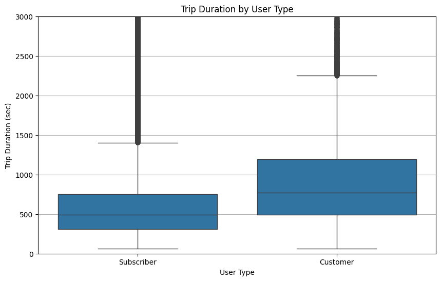

```python
setup_plot(
    title='Trip Duration by User Type',
    xlabel='User Type',
    ylabel='Trip Duration (sec)'
)
sns.boxplot(data=bike_clean, x='user_type', y='duration_sec')
plt.ylim(0, 3000)  # focus on typical range
plt.show()
```

📦 Box Plot: Trip Duration by User Type

This box plot illustrates the distribution of trip durations for Subscribers and Customers:

- **Customers** tend to take longer trips overall, with a higher median trip duration and a wider interquartile range (IQR).
- **Subscribers** have shorter, more consistent trip durations, likely reflecting frequent but brief commutes.
- Both groups show a number of **outliers**, especially for longer trips, but the spread is noticeably greater among Customers.

This visualization reinforces the idea that Subscribers are likely daily users with routine usage, while Customers may be more occasional or recreational riders.

Clustered Bar Chart – user_type vs. day_of_week

```python
# Correct order of the days
day_order = ['Monday', 'Tuesday', 'Wednesday', 'Thursday', 'Friday', 'Saturday', 'Sunday']
```

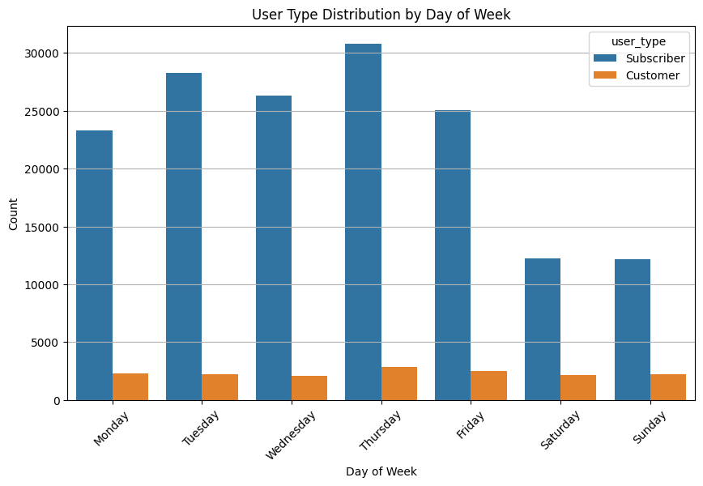

```python
setup_plot(
    title='User Type Distribution by Day of Week',
    xlabel='Day of Week',
    ylabel='Count',
    rotation=45
)

sns.countplot(data=bike_clean, x='day_of_week', hue='user_type', order=day_order)
plt.show()
```

📊 Clustered Bar Chart: User Type Distribution by Day of Week

This visualization effectively reinforces the behavioral distinction between the two user types: structured weekday usage by Subscribers vs. more flexible, leisure-oriented usage by Customers.

🔹 How did the main feature vary with other variables?

- **Trip Duration vs. Start Hour**: Average trip durations are shorter during commuting hours (7–9 AM and 4–6 PM), likely reflecting quick, routine travel. Midday hours (10 AM–3 PM) show longer average durations, suggesting leisure-oriented usage during off-peak times.
- **Trip Duration by User Type**: Customers generally take longer trips than Subscribers. This indicates differing usage patterns — with Subscribers likely using bikes for short, regular commutes, while Customers use them more occasionally and for longer rides.

🔹 Other notable relationships:

- **User Type by Day of Week**: Subscriber usage peaks on weekdays, aligning with workweek routines. In contrast, Customer activity is more balanced but shows a relative increase on weekends, reflecting recreational or flexible usage.

✅ Summary

These patterns support the hypothesis that **trip duration and timing are significantly influenced by user type and day of the week**, revealing two distinct rider behaviors: structured, commuter-driven Subscribers and more flexible, leisure-oriented Customers.

Heatmap: User Type Frequency by Day of Week

Create a Crosstab

```python
bike_clean['day_of_week'] = pd.Categorical(bike_clean['day_of_week'], categories=day_order, ordered=True)

# Crosstab build
heat_data = pd.crosstab(bike_clean['day_of_week'], bike_clean['user_type'])
heat_data
```

| user_type day_of_week | Customer | Subscriber |
| --- | --- | --- |
| Monday | 2268 | 23288 |
| Tuesday | 2246 | 28274 |
| Wednesday | 2075 | 26279 |
| Thursday | 2832 | 30798 |
| Friday | 2515 | 25082 |
| Saturday | 2128 | 12210 |
| Sunday | 2239 | 12180 |

I used crosstab to convert two categorical variables into a numeric matrix that a heatmap can visualize, to know how many times that combo happens.

Plot the Heatmap

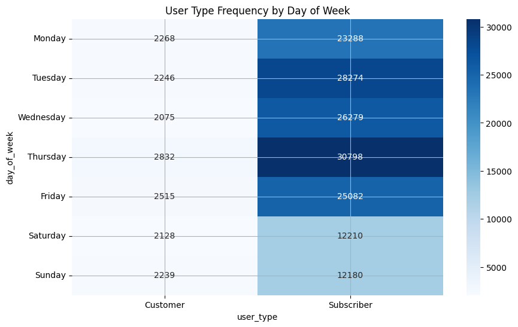

```python
setup_plot(
    title='User Type Frequency by Day of Week',
    xlabel='User Type',
    ylabel='Day of Week'
)

sns.heatmap(
    data=heat_data,
    annot=True,
    fmt='d',
    cmap='Blues'
)
plt.show()
```

🔥 Heatmap: User Type Frequency by Day of Week

This heatmap illustrates the number of trips taken by each user type across different days of the week.

- **Subscribers** show the highest activity on **weekdays**, particularly on **Thursday (30,798)** and **Tuesday (28,274)**. This strongly supports the idea of weekday commuting patterns.
- **Customers** maintain a relatively **low but stable level** of activity throughout the week, with a slight increase on **Thursday (2,832)** and **Friday (2,515)**, though not as sharply on weekends as expected.

While the expected weekend spike for Customers is not as strong, the heatmap still supports the distinction between the **structured, high-volume weekday usage of Subscribers** and the **lower, more consistent usage of Customers**.

This visualization reinforces earlier observations about the differing behaviors between the two user types.

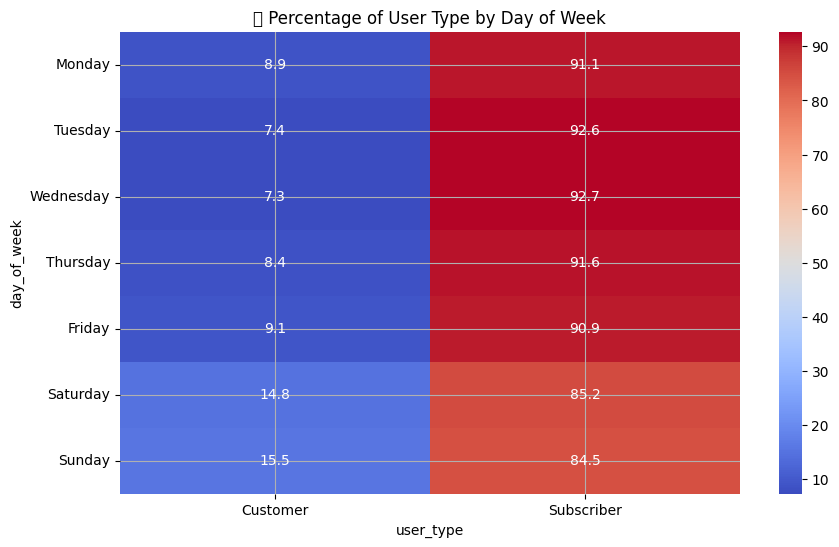

```python
# Normalize by row to get percentages
heat_data_percent = heat_data.div(heat_data.sum(axis=1), axis=0) * 100

# Plot percentage-normalized heatmap
setup_plot(
    title='📊 Percentage of User Type by Day of Week',
    xlabel='User Type',
    ylabel='Day of Week'
)

sns.heatmap(
    data=heat_data_percent.round(1),
    annot=True,
    fmt='.1f',
    cmap='coolwarm'
)
plt.show()
```

Percentage-Normalized Heatmap: User Type Share by Day of Week

This normalized view eliminates the bias of overall volume and clearly highlights behavioral differences: **Subscribers are weekday commuters**, while **Customers are more active on weekends**, supporting the pattern of **commute vs. leisure-based use**.

## Multivariate Exploration

Facet Plot – Start Hour vs. Duration, by User Type

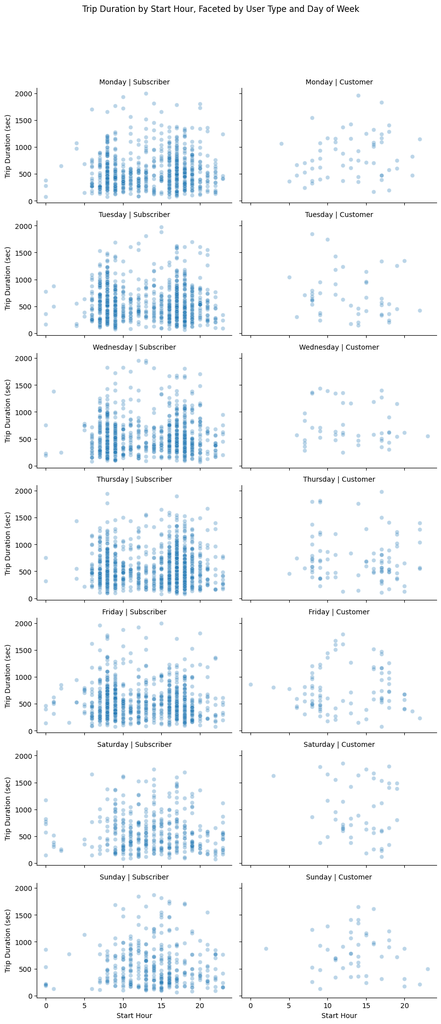

```python
sample_df = bike_clean[bike_clean['duration_sec'] <= 2000].sample(5000, random_state=42)

g = sns.FacetGrid(sample_df, col="user_type", row="day_of_week", height=3, aspect=1.5)
g.map(sns.scatterplot, "start_hour", "duration_sec", alpha=0.3)
g.set_titles(row_template="{row_name}", col_template="{col_name}")
g.set_axis_labels("Start Hour", "Trip Duration (sec)")
plt.subplots_adjust(top=0.9)
g.fig.suptitle("Trip Duration by Start Hour, Faceted by User Type and Day of Week")
plt.show()
```

Faceted Scatter Plot: Trip Duration by Start Hour, Faceted by User Type and Day of Week

This multivariate FacetGrid plot provides a deep view into how **trip duration** varies by **hour of day**, across different **user types** and **days of the week**:

- **Subscribers** (left column) show a **clear concentration during commuting hours**, particularly around **8–9 AM and 5–6 PM**, especially on **weekdays**. Trip durations tend to be shorter and more consistent, highlighting routine usage.
- **Customers** (right column) show **more scattered and longer trips**, especially in the **midday to afternoon** hours. Their activity is more evenly distributed and notably visible on **weekends**, supporting the idea of **recreational or casual usage**.

The plot reinforces previous findings:

- **Subscribers** use the system mainly on weekdays with shorter durations tied to commuting.
- **Customers** are less predictable and tend to ride longer during off-peak hours, particularly on **Saturday and Sunday**.

This visualization strengthens the conclusion that **time, user type, and day of week interact meaningfully** to shape how and when people use the bike-sharing system.

Faceted Count Plot: Bike Share for All Participation by Gender and User Type

```python
bike['user_type'].unique()
```

```
array(['Subscriber', 'Customer'], dtype=object)
```

```python
bike['member_gender'].unique()
```

```
array(['Male', 'Female', 'Other'], dtype=object)
```

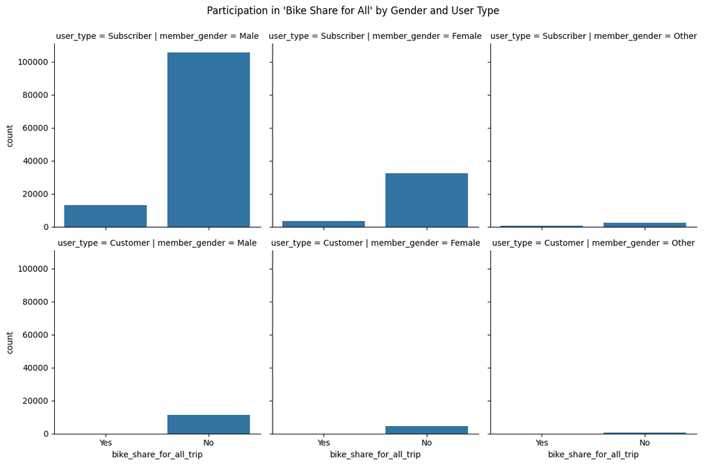

```python
sns.catplot(
    data=bike_clean,
    kind="count",
    x="bike_share_for_all_trip",
    col="member_gender",
    row="user_type",
    height=4,
    aspect=1
)
plt.subplots_adjust(top=0.9)
plt.suptitle("Participation in 'Bike Share for All' by Gender and User Type")
plt.show()
```

Faceted Count Plot: Bike Share for All Participation by Gender and User Type

This plot breaks down participation in the **"Bike Share for All"** program across different **user types** and **genders**:

- **Subscribers** (especially male) are more frequently enrolled in the program.
- **Customers** participate far less, with very low counts for all genders.
- **Female users** seem to participate less overall than male users, across both user types.

This visualization helps highlight how demographic factors like **gender** and **membership status** influence participation in accessibility-focused programs.

Were there features that strengthened each other in terms of looking at your feature(s) of interest?

Yes. The **FacetGrid scatter plot** combining `start_hour`, `duration_sec`, `user_type`, and `day_of_week` helped reinforce earlier insights. It showed how trip durations tend to be shorter and more consistent during peak commuting hours for **Subscribers**, while **Customers** took longer trips during non-peak hours, especially on weekends.

This combination of features—**time of day, day of week, and user type**—clearly strengthened the understanding of trip duration behavior and validated patterns seen in earlier univariate and bivariate plots.

Were there any interesting or surprising interactions between features?

Yes. In the **faceted count plot of "Bike Share for All" participation**, it was surprising to see that:

- **Male Subscribers** are the most frequent participants in the program.
- **Customers**, across all genders, showed **very low participation**, even though the program is designed for affordability and accessibility.

This suggests that the program may be more visible or appealing to long-term users (Subscribers) rather than occasional riders (Customers), and gender may also play a role in program awareness or accessibility.

These findings demonstrate how multivariate analysis can reveal hidden patterns and provide more context for interpreting user behavior.

## Conclusions

This data exploration of the Ford GoBike system (February 2019) revealed valuable insights into how bike usage patterns vary by time, user type, gender, and participation in public access programs.

🧠 Reflection on the Exploration Process

- The analysis began with **basic wrangling and cleaning** (handling null values and filtering unrealistic durations).
- **Univariate exploration** helped understand the structure of key variables.
- **Bivariate analysis** revealed patterns between time, user type, and duration.
- **Multivariate visualizations** added depth, exposing behavioral patterns and demographic participation in public programs.

This project clearly demonstrates how thoughtful data visualization helps uncover **user behavior trends**, **program reach**, and **urban mobility patterns**, which can directly inform decisions in urban planning and accessibility policy.